# Second Day

### Complex network's statistical properties

- Feedback on assignments
- The importance of degree distribution
- Modeling networks and the small world effect
- Cohesiveness and resilience of a network
- Community detection

## Degree Distribution

Social and comunication networks include several thosusands of nodes making difficult to understand the relations among nodes.

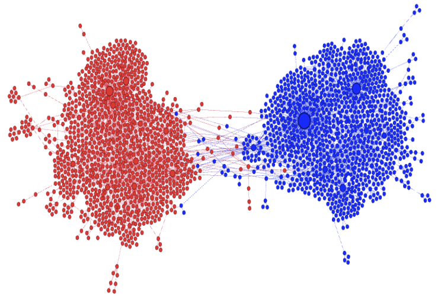

### statistical approach

- how centrality measures are distributed among nodes.(Statistical distributions)
- The idea of distribution is not far from that of histogram: the height of the bar corresponds to the count of observations (nodes)having a specific value .
- Divide the height by the total number of nodes $N$ -> relative frequency.
- For large values of observation ($N$ large) the frequency tends to the probability $p_k$ that is the the probability that a randomly selected node has degree $k$

The degree distribution is the basis of many network-related phenomena, from resilience to virus dissemination. Depending on the shape of $p_k$ a network is described as a random network (or Erdos Renyi) or a power-law distribution with different properties.

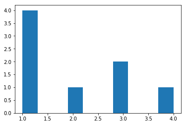

```python
def plot_degree_dist(G,density):
    degrees = [G.degree(n) for n in G.nodes()]

    if density=="density":
        #weights = np.ones_like(degrees)/float(len(degrees))
        #pl.hist(degrees, weights=weights)
        sns.distplot(degrees)
        pl.title("L={}".format(G.number_of_edges()))
        pl.xlim(1, max(degrees)+10)
    else:
        pl.hist(degrees)
    pl.show()
df = pd.read_csv("toy_network_1.csv",sep=";")
Graphtype = nx.Graph()
Gund = nx.from_pandas_edgelist(df,source="Origin",target="Destination",edge_attr=None,  create_using=Graphtype)
plot_degree_dist(Gund,"No")
```

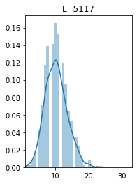

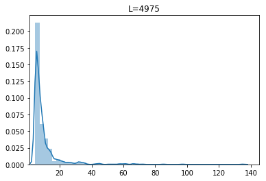

```python
pl.subplot(1, 2, 2)
G1 = nx.erdos_renyi_graph(1000, 0.01)
plot_degree_dist(G1,"density")

pl.subplot(1, 1, 1)
G2 = nx.barabasi_albert_graph(1000, 5)
plot_degree_dist(G2,"density")
```

Knowledge of degree distribution -> estimate momenta of the distribtuion

$$< k^n>=\int k^n P(k) $$

Heterogeenity factor

$$\kappa=\frac{<k^2>}{<k>}$$

For homogeneous distribution the degree distribution is similar to a Poissonian one , centered on the average degree, thus $\kappa \simeq <k>$. For heavy tail distribution the variance scales with the size of the network and then is much higher than 1.

- $\kappa$, in the case of uncorrelated networks, corresponds to the average degree of nearest neighbors
- $\kappa$ provides information about connectivity of the network
- $\kappa$ determines if disease spread or not

## Modeling Networks

The degree distribution,and the corresponding structure, depends on the dynamics at the base of the network formation. In some cases this dynamic can be modelled through some mathematical models.

### Erdos Renyi network and randomness (1960)

Links are established at random among a set of $N$ *fixed* nodes. Two alternative ways of describing it:

```
1 We consider that we have a set of $N$ nodes and a set of $L$ links whose ends are  selected randomly
2 We can consider a set of $N$ nodes whose $N(N-1)/2$ possible links can be present  with probability $p$ or absent with probability $1-p$. That is equivalent to say that  the probability that 2 nodese are connected is $p$
```

The two formulation are connected.

In the first formulation the average degree $<k>=\frac{2 L}{N}$

In the second case we can immagine the probability of creating a link between 2 nodes corresponds to toss a coin with a probability $p$ of success for a number of trials $N(N-1)/2$. The average number of success (binomial distribution) is

$<L>=\frac{1}{2}N(N-1)p$

and consequently the average degree

$<k>=\frac{2 <L>}{N}=(N-1)p\simeq N p$

for large $N$ the two formulations are equivalent

Real-networks are mostly characterized by a finite degree $<k>$ , so we can redefine $p$ in such a way that also for a infinte the degree remains finite

$p=\frac{ <k>}{N-1}\simeq \frac{ <k>}{N}=d$.

In this case we note that the probability $p$ of creating a link and the density of a network $d$: that is the density correspond to the probability of creating a link between 2 nodes.

To estimate the degree distribution we consider that in a network with probability $p$ the probability of finding a node of degree $k$ is equal to the probability that on $N-1$ trials $k$ will be successfull and $N-1-k$ unsuccessfull (binomial distribution). $N-1$ corresponds to the number of maximum links that a node could establish

$$ P(k)=( \begin{array}\\ N-1\\ k \end{array} )p^k(1-p)^{N-1-k} $$

In the limit $N$ goes to infinite while $<k>$ remains constant the binomial distribution can be approximated by a Poissonian one

$$ P(k)=e^{-<k>}\frac{<k>^k}{k!} $$

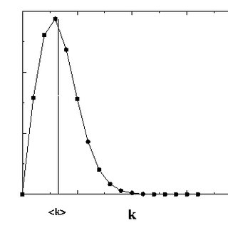

nx.gnp_random_graph(n=100,p=0.1)

nx.gnm_random_graph(n=100,m=10)

## Some characteristics:

- peaked around $<k>$, with an exponential decay for large $k$
- The Poisson distribution does not explicitly depend on the number of nodes $N$.
- Probability that 2 nodes of its neighborhood are connected is given by the probability $p$, clustering coefficient $$ C_i=p=\frac{<k>}{N}$$
- **for fixed average degree, the clustering coefficient is decreasing with the size of the network**
- _*clustering coeefficient* of a node is indipendent of the node's degree
- Connectivity there is a *phase transition* occuring when $<k>>1$, i.e. for $<k><1$ the fraction of connected nodes is infinitesimal while for $<k>>1$ a finite fraction of the network is connected. For $<k>>ln(N)$ all nodes are connected

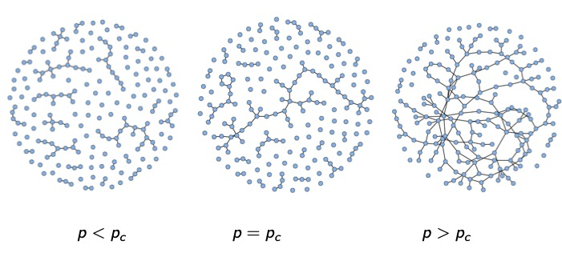

- Moreover the condition $<k>>1$ can be translated as $\kappa>2$ for an Erdos Renyi Network

  $$<k> >1 \rightarrow \kappa=\frac{<k^2>}{<k>}>2$$

### small world effect

- Distance If we consider that in average , each node in a network has $<k>$ nodes at distance 1, starting from a node $s$, at distance $n$ there will be $<k>(<k>-1)^{(n-1)}$ reachable, the diameter $l_{max}$ can be estimated as the distance at which all the nodes $N$ will be reached:

$$ <k>^{l_{max}}\simeq N \rightarrow l_{max}=\frac{log(N)}{log(<k>)} $$

the distance between nodes is much smaller than the size of the network.

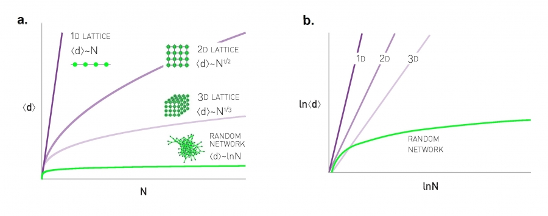

## Watts strogatz model

$$<C>/<k> \sim 1/N$$

,

- Real networks the quantity is not decreasing with $N$ .
- Real networks clustering coefficient depends on the degree of the nodes. **Real network appears to have larger clustering coefficient and at the same exhibit small world effect**. The Erdos Renyi model doesn't capture these 2 phenomena at the same time.

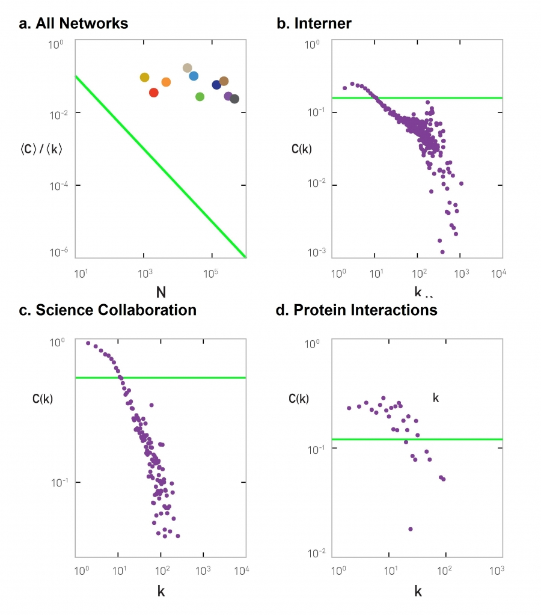

**To consider the 2 properties, Watts and Strogatz proposed a new model whose network could exibit both the properties: small diameter and finite clustering coefficient**

The model interpolates between a regular lattice on a circle , with clustering coefficient 1 and $l_{max} \sim N$, and a random one, with almost null clustering coefficient and diameter scaling as $ln N$.

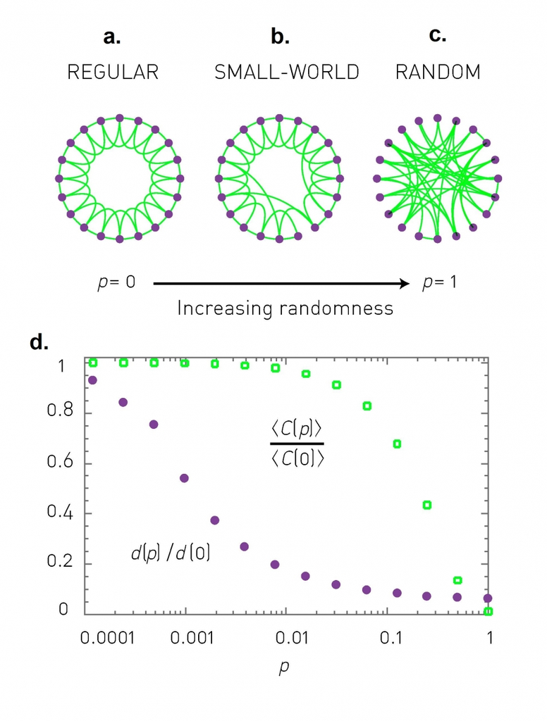

For a specific value of the triad $N , k, p$ a Watts-Strogatz model can be created using the function

GWS=nx.watts_strogatz_graph(1000,4, 0.1)

## Barabasi Albert model and the scale free network

Real networks are characterised by the presence of *hubs*, nodes with a large number of connections To recover the hubs we need to create a mechanism that favours certain nodes over others:*preferential attachment*, "we try to stick to famous people to be noted".

- We consider an initial set of $m_0$ nodes that are connect among them.
- At each time we add an ew node $i$ with $m$ links ($m<m_0$)
- *Preferential attachment* : the node can create link with a previously existing node with a probability based on its "popularity"

$$\Pi (ij)=\frac{k_j}{\sum_k k_k}$$

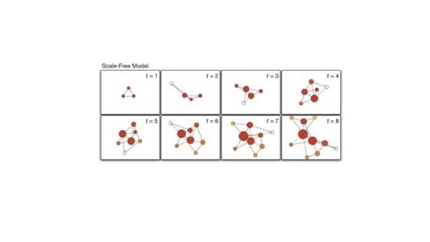

The resulting degree distribution can be written has

$$ P(k)= Ck^{-\gamma}$$

where $C$ is a normalizing constant and $\gamma $ is a positive constant, depending on $m$. The degree distribution is called a power-law or scale free

This model was firstly introduce by Barasi Albert to explain the skewness of the degree distribution of internet finding an exponent $\gamma=3$

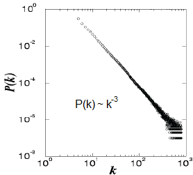

The Barabasi Albert network can be created using the function networkx ,defining the sie of the network chosen $N$ and the number of new links created at each time $m$:

GBA=nx.barabasi_albert_graph(2000,4)

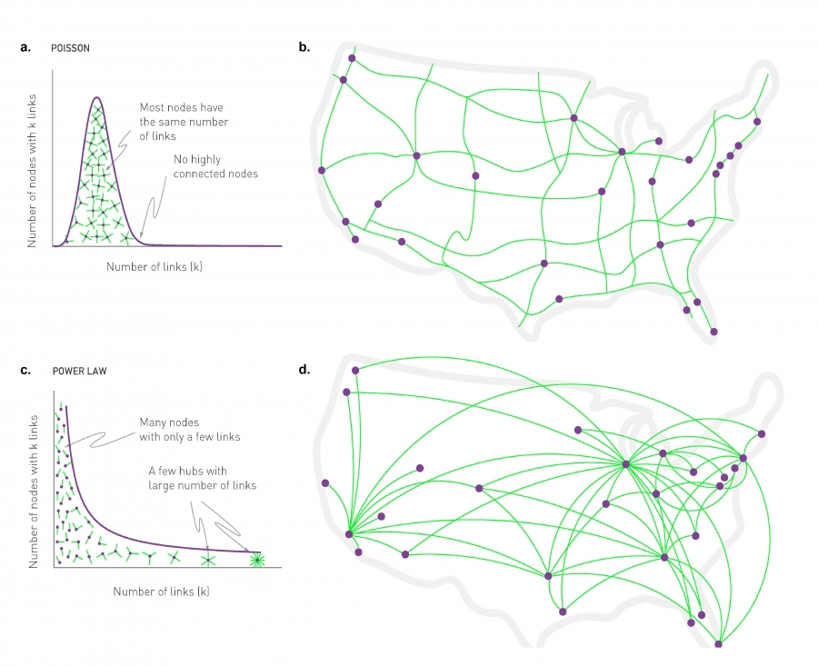

- Largest degree values depend on network size

$$k_{max}=k_{min}N^{\frac{1}{\gamma-1}}$$

- Momenta have a strongly dependence on the the size of the network itself

$$< k^n>=\int k^n P(k) = \frac{k_{max}^{n-\gamma+1}}{n-\gamma+1} -Q \simeq \frac{N^{\frac{n}{\gamma-1}-1}}{n-\gamma+1}_Q$$

- $2< \gamma < 3$ the first moment is finite but the second moment is infinite. Divergence of $<k^2>$ for large N -> fluctuations around the average can be arbitrary large-> scale free.
  - scale-free -> lack of an internal scale, a consequence of the fact that nodes with widely different degrees coexist in the same network.
  - If we scale the degree by a constant factor the distribtution would have still the same form. This is not possible in homogeneous network since the distribution is peaked around specific values.

Some properties of scale free network:

- The coefficient $\gamma$ , has an effect on the values of the momenta.

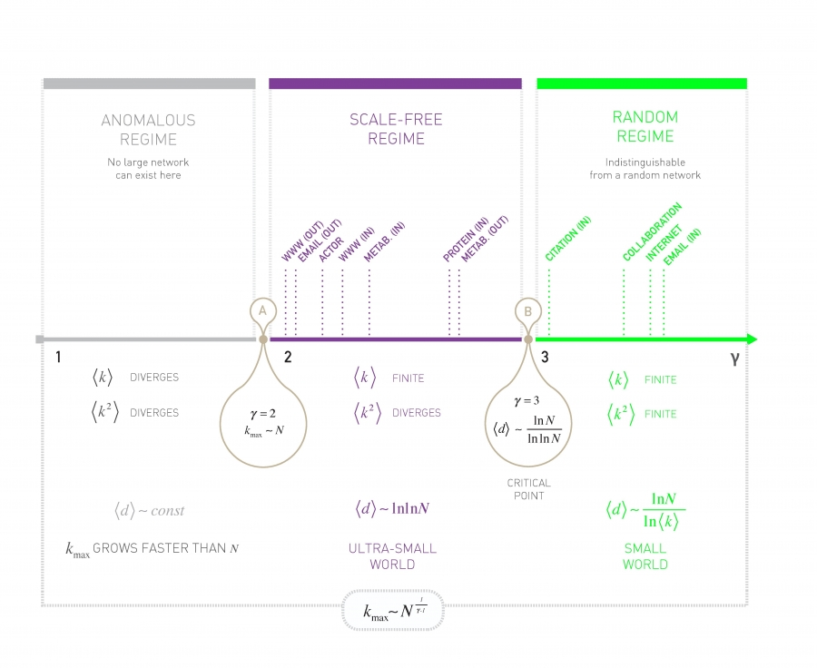

- Closeness to hubs: most of low-degree nodes are connected directly to hubs

Before concluding the session a remark on plotting degree distribution. Because of the power law distribution , to estimate the coefficient $\gamma$ would be ideal to plot the degree distribution in a log-log plot. However using a linear binning , that is a bin of size one , (to estimate the number of ndoes with rpecisely degree k) would make the interpretation difficult , since for large $k$ few nodes will be present and the distribution would present a plateau (i.e. same number of counts for different values of $k$). A way to avoid this is to use a **log-binning** , that is, to create bins of increasing width $b^n$, so that in $n$ bins there will be the nodes with degree between $b^n $ and $b^{n+1}$. The below function shows how to do it:

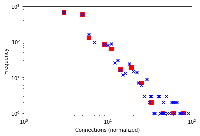

```python
from collections import Counter
def drop_zeros(a_list):
    return [i for i in a_list if i>0]



GBA=nx.barabasi_albert_graph(2000,4)
ba_c = nx.degree_centrality(GBA)
ba_c = {k:int(v*(len(GBA)-1)) for k,v in ba_c.iteritems()}
ba_c2 = dict(Counter(ba_c.values()))


max_x = np.log10(max(ba_c2.keys()))
max_y = np.log10(max(ba_c2.values()))
max_base = max([max_x,max_y])
min_x = np.log10(min(drop_zeros(ba_c2.keys())))

bins = np.logspace(min_x,max_base,num=20)
widths = (bins[1:] - bins[:-1])
bin_means_y = (np.histogram(ba_c2.keys(),bins,weights=ba_c2.values())[0] / np.histogram(ba_c2.keys(),bins)[0])
bin_means_x = (np.histogram(ba_c2.keys(),bins,weights=ba_c2.keys())[0] / np.histogram(ba_c2.keys(),bins)[0])

pl.xscale('log')
pl.yscale('log')
pl.scatter(bin_means_x.tolist(),bin_means_y.tolist(),c='r',marker='s',s=50)
pl.scatter(ba_c2.keys(),ba_c2.values(),c='b',marker='x')
pl.xlim((1e0,1e2))
pl.ylim((.9,1e3))
pl.xlabel('Connections (normalized)')
pl.ylabel('Frequency')
pl.show()
```

#### Other types of preferential attachment

Previous model has consider linear preferential attachment Howevere other two models acan be considered:

- Non linear preferential attachment

  $$\Pi (ij)=\frac{k_j^\alpha}{\sum_k k_k^\alpha}$$
  - where for $\alpha<1$ hubs disappear
  - where for $\alpha>1$ hubs accumulate links faster than younger nodes and in the $\alpha>2$ a single node can take all the connections (*winner takes all effect*)
- Fitness model In this case node $i$ has a fitness value assigned $\eta_i$ that could attract links. This fitness node could corresponds to some propoerties of the node not related to the structure.

  $$\Pi (ij)=\frac{\eta_j k_j}{\sum_k\eta_k k_k}$$

  If values of fitness are bounded there re multiple hubs; fitness equilibrate age in the network

#### Not all the networks are scale-free

| Scale Free | Not Scale free |
| --- | --- |
| Internet | Neural network C. Elegans |
| Sexual Network | Crystal/lattice |
| Airports | Road Network |

## Robustness and resilience of the networks

**Resilience: capacity of a network to maintian its fucntion after the failure of nodes**.

[figure not shown]

2 types of faliures:.

```
Error: is a random failure of a node
Targeted attack: nodes with specific characteristics are removed from the network (pruning)
```

In order to assess the resilience of a network ,following a random or targeted attack:

```
 A node is elected  , either by random choice or based on criteria

 Selected node is removed  together with all its links

 The connectedness of the network is checked as the fraction of nodes in the Giant Component over all networks.

 We remove another node
```

We usually study how the size of the giant component varies in term of the fraction of removed nodes $f$.

The scale-free networks are more vulnerable to targeted attacks (targeted vaccination)

[figure not shown]

### Molloy-Reed criterion

For a network to have a giant component, most nodes that belong to it must be connected to at least two other nodes. Therefore, the average degree $k_i$ of a randomly chosen node i that is part of the giant component should be at least 2. This condition translates in

$$\kappa= \frac{<k^2>}{<k>}>2$$

For a node probability that after $f$ nodes removal there are still $k_f$ of $k$ original connections is given by

$$ P(k)=( \begin{array}\\ k\\ k_f \end{array} )(1-f)^{k_f}(f)^{k-k_f} $$

$$ \begin{array}\\ <k>_f=(1-f)<k> \\ <k^2>_f=(1-f)^2<k>^2+f(1-f)<k> \end{array} $$

The fraction to remove is related to this coefficient by the relation

$$ f_c=1-\frac{1}{\kappa-1}$$

In the case of Erdos Renyi network is a finte values<1

For scale free network , due to the fluctuation of heterogeneity , $f_c=1$ that means the system is more tolerant to random failures

In the case of targeted attack for a scale free network the removal of highest degree nodes modify the degree distribution , and the surviving graph is with a cut-off with nodes can removed with a probability taht depends again on the fluctuation of degree distribution

## Community structures in network

**Communities : a set of nodes that are tightly connected among themselves and the density of the set is higher than the average density of the network**. The formation of these clusters could depend on several exogeneous factors (social , economical). The presence of communities could help us in understanding how network is organized and the function it serves: in brains communities of synapies are synchronise;in protein-protein interaction group of connected proteins are associated with a particular biological function. Once communities are identified , we can proceed to classify the role of nodes inside each communtiy: nodes at the center represents core of the cluster, whilst nodes at the border between communities act as gatekeepers different parts of the network.

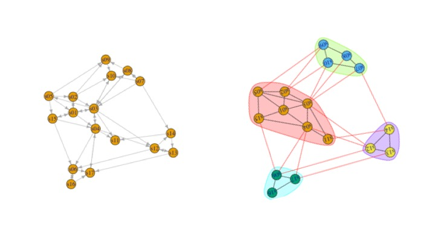

Some definition:

- Community is a connected subnetwork whose internal degree (that is the number of links excahnged among members) is higher than external one (links with nodes of other communities)
- Communities are said to have high *cohesion* (large number of internal links) and high *separation* (they are poorly connected with other communities).
- The community degree is the sum of all the degrees of a community $$K_C=\sum{i in C}k_i=\sum{i in C}k_i^{int}+k_i^{ext}$$
- **Modularity** is the difference between the number of links internal to a community ($L_C$) and the ones that could be obtained in a randomized network with the same degree distribution: the higher the value the more the distribution is not randomly but there are some driving forces.

  $$ M=\frac{1}{L} \sum_C(L_C-\frac{K_C^2}{4L})$$

  where $\frac{K_C^2}{4L}$ is the probability that 2 nodes in the commuity are connected by chance
- hierarchical procedure to identifying communities (dendrograms)

2 algorithms can be considered to identify communities:

- **Girvan Newman Algorithm or edge betweenness**: the main assumption is that link with highest betweenness connect nodes in different communities (bridge). Thus removing thes links we identify communities. The algorithm works in 2 repetetive steps:
  - The link with highest betweenness is removed
  - The betweenness is re-estimated
  - The first stpe is repeated till all the links are removed. At the end the network is partition ed in $N$ communities taht are part of the dendrogram

[figure not shown]

The function for the Girvan_Newman:

partitionGN=nx.community.girvan_newman(GBA)

To estimate the modularity for a partition

modularityGN=nx.community.quality.modularity(GBA,partitionGN)

- **Modularity Optimization** The Louvain algorithm works to merge partition and increase the modularity of the network. Initially nodes are communities *per se*. Connected nodes are merged together to form temporary communities. Temporary communities are merged in supernodes with weighted links whose weights correspond to the number of links exchanged by the nodes in the communinties.

[figure not shown]

Both the algorithms produce partiitions, to compare and decide the betst partition , and which algorithm detect more precisely the community partition the rule of thum of modularity >0.3 is used.

For the Louvain a function has not been developed yet, but for a generic modularity greedy:

partitionGreedy=nx.community.greedy_modularity_communities(GBA)

## Some applications of network theory

### The case of transmission of disease

- S: (susceptible, they ahven't experienced the disease),
- I (infectious, they can infect other),
- R (removed , they have been infected but now they have accquired immunity).

$$ \begin{array}\\ \frac{ds}{dt}=- \beta*s*i\\ \frac{di}{dt}=\beta*s*i-\mu*i\\ \frac{dr}{dt}=\mu*i \end{array} $$

The model assume homogeneous mixing , i.e. the probability of entering in contact with all the population is the same for all members .

This model as theshold parameter $R_0$ whose value>1 indicates that a disease could occur:

$$R_0=\frac{\beta N}{\mu}>1$$

Real life experience -> finite number of contacts everyday $<k>$. Probability of getting infected if there are $i$ infectious individual is

$$ 1-(1-\beta dt)^{<k>i}\sim \beta <k>i dt$$$$ \begin{array}\\ \frac{ds}{dt}=- \beta <k>*s*i\\ \frac{di}{dt}=\beta<k>*s*i-\mu*i\\ \frac{dr}{dt}=\mu*i \end{array} $$

and

$$R_0=\frac{\beta <k>}{\mu}>1$$

Population with different degree-> classes of nodes based on the degree

A set of equations for each class

$$ \begin{array}\\ \frac{ds_k}{dt}=- \beta *k *s_k*\theta(k)\\ \frac{di_k}{dt}=\beta *k *s_k*\theta(k)-\mu*i_k\\ \frac{dr_k}{dt}=\mu*i \end{array} $$

$\theta(k)$ indicates the fraction of neighbours that are infected. This latter can estimated on an uncorrelated network by the probability that a node with degree $k$ is connected to a degree with degree $k'$:

$$\theta(k)=\sum_{k'}\frac{(k'-1)*P(k')}{<k>}i_{k'}$$

$$R_0=\frac{\beta }{\mu}(\frac{<k^2>}{<k>}-1)=\frac{\beta }{\mu}(\kappa-1)$$

When fluctuations are finite the ratio $\beta/\mu$ should be finite. When fluctuations are large , also disease with a low value of transmissibility can spread

### The case of gene regulatory netowrk: the Kauffman model

Each node corresponds to a gene who could be either activated (1) or not (0) . Boolean Network: state of a node $\sigma_i$, at time $t+1$ is given by a function of the states of its randomly chosen in-neighbors $j$

$$\sigma_i(t+1)=F_i[\sigma_j(t)]$$

$F$ gives 1 with a probability $p$ , 0 with probability $1-p$.

For a set of $N$ genes there are $2^N$ possible configurations and after $2^N$ steps tha system reach a configuration already met (called attractor). the different types of attractor correspond to differnt cells that differ by patterns of gene activities.

System is an ordered state ( the value of genes doen't change intime even if perturbed) or chaotic (small perturbations can move the system)

#### Using ER network

First model used a Erdos Renyi model and consider that each gene was connected in average to $K$ other genes (in-neigbhors)

System is in an ordered pahse if $K<K_c$

$$K_c=\frac{1}{2p(1-p)}$$

where $p$ is the probability of activation.

#### Using different topologies

Stability depends on the first momentum.

Scale-free network topologies lead to stable solutions: nodes with in-degree 1 that are automatically frozen; also hubs in contact with nodes of low in-degree. $\gamma$ exponent of the power law has huge effect on the pahse transition.

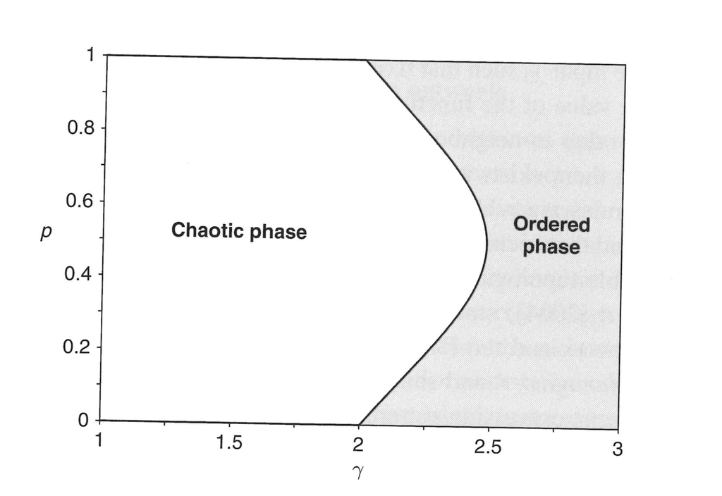

## Assignement 2

In the folder 1_Data you will find 6 csv files representing the network edgelist (Network_1.....6.csv) All the networks are undirected and unweighted except Network_3 (oriented and weighted) and Network_6 (oriented)

Divided in 2 groups,

- Group A: Network_1, Network_2, Network_3
- Group B: Network_4, Network_5, Network_6

analyse the networks.

- For each network describe the gloabl measures and the degree distribution. If you suspect that a network has a power -law degree distribution use the log-binning in the plot What are the differences among the networks?
- Study the resilience of the networks 1 and 3 (GroupA) , 4 and 6 (Group B) to random and targeted attack (use the networkx function remove.node()) and plot the size of the giant component as a function of the removed node (f).
- Use the 2 algorithms for community detection on the network. Which one is the best?

If you have the possibility try to plot the networks using gephi

You can present your results on power point